# MQuinho de inverno - R para análise de dados (script)

## 10. Gráficos com o ggplot2

### 10.1. A Gramática dos Gráficos: componentes de um gráfico ggplot2

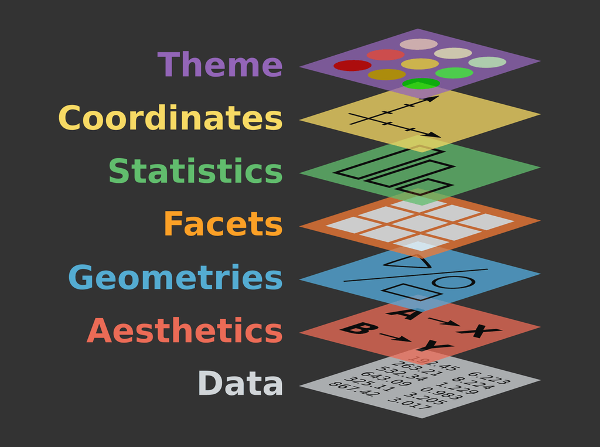

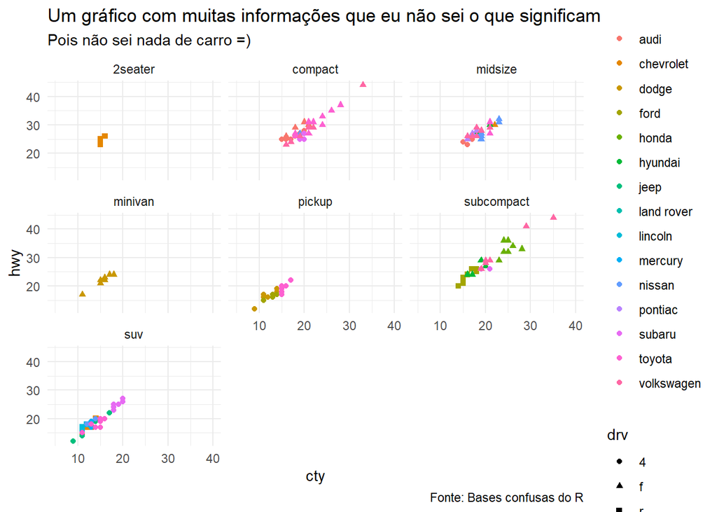

```r
# Um gráfico com todos os componentes

mpg %>%                                             # Data
  ggplot(mapping = aes(x = cty,                     # Aesthetics 1 (X)
                       y = hwy,                     # Aesthetics 2 (Y)
                       colour = manufacturer,       # Aesthetics 3 (Colour)
                       shape = drv)) +              # Aesthetics 4 (Fill)
  geom_point() +                                    # Geometries, Statistics
  facet_wrap(~ class) +                             # Facets
  xlim(5,40) +                                      # Coordinates
  labs(title = 'Um gráfico com muitas informações que eu não sei o que significam',
       subtitle = 'Pois não sei nada de carro =)',
       caption = 'Fonte: Bases confusas do R',
       y = 'hwy',
       x = 'cty',
       colour = '') +                               # Labels
  theme_minimal()                                   # Theme
```

1. **Data (Dado)**

Não existe gráfico se não há dado, a qualidade do dado e as manipulações feitas previamente são as únicas fontes de informação para os comandos executados no ggplot2.

2. **Mapping (Mapeamento de eixos)**

Mapeamento do dado no plano cartesiano. O que estará no eixo X? O que estará no eixo Y? Eu gostaria que minhas observações fossem dividas por alguma outra variável?

3. **Statistics (Estatísticas padrão)**

Dentro de cada “geom_” existe uma série de padrões (defaults) que facilitam consideravelmente nossa vida na hora de plotar um gráfico. O gráfico de barras, por exemplo, tem o eixo Y fixado como a soma das linhas para cada categoria de X, ou seja, contagem. Boxplots calculam a mediana, os quartis e definem os outliers automaticamente, etc.

4. **Scales (Escalas)**

As escalas são outros tipos de mapeamento que não apenas o eixo X e Y. É possível dividir as observações de um gráfico de pontos por cores ou formatos diferentes dos pontos, por exemplo.

5. **Geometries (Forma geométrica)**

Os geoms, ou geometries, são os responsáveis por representar aquilo que foi estabelecido como o mapeamento dos eixos (x, y e scales) numa forma geométrica escolhida.

- geom_bar() e geom_col() para gráficos de barras
- geom_histogram() para histogramas
- geom_boxplot() para boxplots
- geom_point() para diagramas de dispersão
- geom_line() para linhas
6. **Facets (Lados/perspectivas/faces)**

Os Facets nos possibilitam criar diversos gráficos de uma só vez num mesmo plano cartesiano. Posso querer, por exemplo, saber a variação da renda por idade por escolaridade em dois anos diferentes e quem faz isso por mim é o facet_wrap().

7. **Theme (Temas)**

Propriedades estéticas gerais que não são indispensáveis para interpretação.

### 10.2. Mão na massa: gráficos por tipo

A estrutura básica de um argumento ggplot é composta de:

1. Um objeto que contenha os dados que serão plotados; no formato correto
2. A função ggplot(), seguido do mapeamento dos eixos X e Y do seu gráfico e algum argumento de escala opcional
3. Um argumento de definição do tipo de gráfico - Forma geométrica (geom_)
4. É importante lembrar que operador de continuidade do ggplot não é o pipe ‘%>%’ , mas sim um sinal ‘+’.

   > No ggplot nada se transforma, tudo se adiciona. Por isso o operador +.